# Select and Mutate

MPA 634: Data Science for Managers

9/23/2019

## Give multiple ways to select dep_time, dep_delay, arr_time, and arr_delay from the flights data frame.

```r
variables <- c("dep_time", "dep_delay", "arr_time", "arr_delay")
departure_delays <- flights %>%
  select(variables)
departures_delays <- flights %>%
  select(dep_time, dep_delay, arr_time, arr_delay)
departures_delays <- flights %>%
  select(starts_with("dep"), starts_with("arr"))
departures_delays <- flights %>%
  select(ends_with("time"), ends_with("delay"))
departures_delays <- flights %>%
  select(4, 6:7, 9)
```

## Calculate the difference between dep_time and sched_dep_time and compare the result with dep_delay. How do we explain the difference?

- Use transmute to calcuate the new time difference
- Compare dep_time with your calculation to see where they are different
- Choose the first 20 observations

```r
departure_comparison <- flights %>%
  transmute(
    dep_time,
    sched_dep_time,
    dep_delay,
    time_difference = dep_time - sched_dep_time,
    same = (dep_delay == time_difference)
  )
head(departure_comparison, 20)
```

```
## # A tibble: 20 x 5
##    dep_time sched_dep_time dep_delay time_difference same
##       <int>          <int>     <dbl>           <int> <lgl>
##  1      517            515         2               2 TRUE
##  2      533            529         4               4 TRUE
##  3      542            540         2               2 TRUE
##  4      544            545        -1              -1 TRUE
##  5      554            600        -6             -46 FALSE
##  6      554            558        -4              -4 TRUE
##  7      555            600        -5             -45 FALSE
##  8      557            600        -3             -43 FALSE
##  9      557            600        -3             -43 FALSE
## 10      558            600        -2             -42 FALSE
## 11      558            600        -2             -42 FALSE
## 12      558            600        -2             -42 FALSE
## 13      558            600        -2             -42 FALSE
## 14      558            600        -2             -42 FALSE
## 15      559            600        -1             -41 FALSE
## 16      559            559         0               0 TRUE
## 17      559            600        -1             -41 FALSE
## 18      600            600         0               0 TRUE
## 19      600            600         0               0 TRUE
## 20      601            600         1               1 TRUE
```

## Replicate the calculation of dep_delay

- Create a new data frame (departure_calculations) from flights that
  - Converts dep_time into minutes from midnight
  - Converts sched_dep_time into minutes from midnight
- View dep_time, sched_dep_time, del_delay and their calculated equivalents

```r
departure_calculations <- flights %>%
  transmute(
    dep_time,
    sched_dep_time,
    dep_delay,
    dep_minutes = dep_time %/% 100 * 60 + dep_time %% 100,
    sched_dep_minutes = sched_dep_time %/% 100 * 60 + sched_dep_time %% 100,
    dep_delay_calculated = dep_minutes - sched_dep_minutes
  )
departure_calculations %>%
  head(5)
```

```
## # A tibble: 5 x 6
##   dep_time sched_dep_time dep_delay dep_minutes sched_dep_minut~
##      <int>          <int>     <dbl>       <dbl>            <dbl>
## 1      517            515         2         317              315
## 2      533            529         4         333              329
## 3      542            540         2         342              340
## 4      544            545        -1         344              345
## 5      554            600        -6         354              360
## # ... with 1 more variable: dep_delay_calculated <dbl>
```

## Transform scatterplot of diamonds

### Draw a scatter plot of price on diamond weights

- Use the diamonds data frame
- The price of diamonds is given by price
- The weight of the diamonds is given by carat
- Use transparency to help with the overplotting of so many observations
- Add a loess smooth without the confidence interval
- Add a simple regression line without the confidence interval

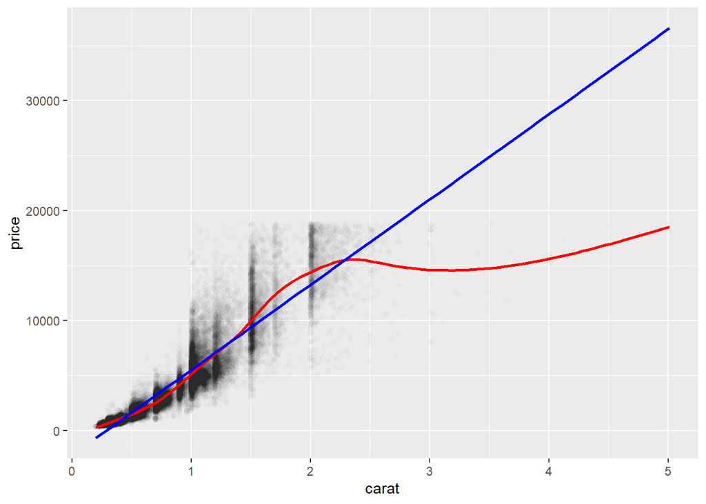

```r
diamonds %>%
  ggplot(mapping = aes(x = carat, y = price)) +
  geom_point(alpha = 1 / 100) +
  geom_smooth(color = "red", se = FALSE) +
  geom_smooth(method = "lm", color = "blue", se = FALSE)
```

### Scale price and carat by subtracting the mean and dividing by the standard deviation

- Create a new data frame that includes scaled values for price and carat
- Draw a scatterplot with transparency, loess, and simple regression as before

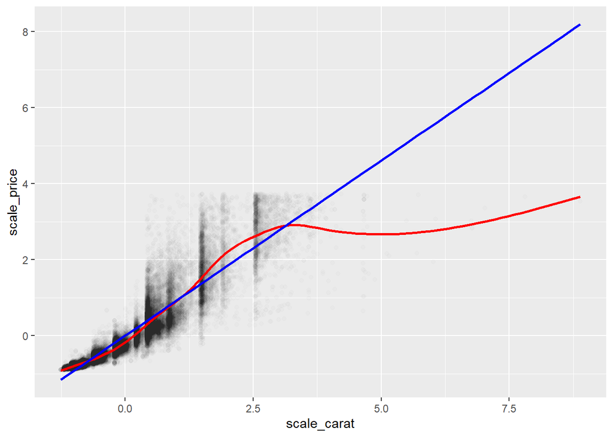

```r
diamonds %>%
  transmute(
    scale_price = (price - mean(price, na.rm = TRUE)) / sd(price, na.rm = TRUE),
    scale_carat = (carat - mean(carat, na.rm = TRUE)) / sd(carat, na.rm = TRUE)
  ) %>%
  ggplot(aes(x = scale_carat, y = scale_price)) +
  geom_point(alpha = 1 / 100) +
  geom_smooth(color = "red", se = FALSE) +
  geom_smooth(method = "lm", color = "blue", se = FALSE)
```

### Try a logarithmic transformation of price and carat

- Create a new data frame that includes logarithmic transformed variables for price and carat
- Draw a scatterplot with transparency, loess, and simple regression as before

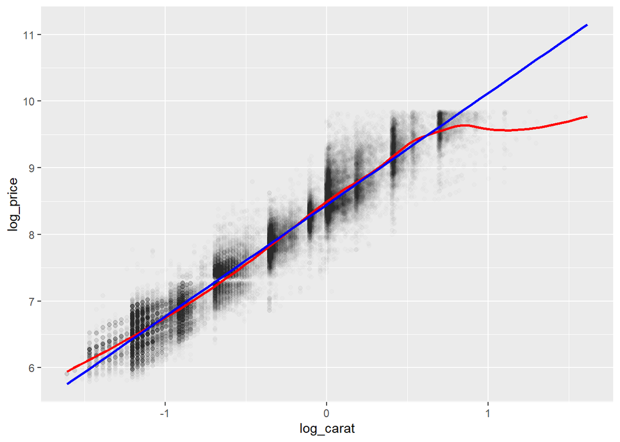

```r
diamonds %>%
  transmute(log_price = log(price),
            log_carat = log(carat)) %>%
  ggplot(mapping = aes(x = log_carat, y = log_price)) +
  geom_point(alpha = 1 / 100) +
  geom_smooth(color = "red", se = FALSE) +
  geom_smooth(method = "lm", color = "blue", se = FALSE)
```

### We often don’t need to create new variables because we have functions that accomplish transformations. Two of these often used transformations are the functions scale and log. We can actually use these transformations within ggplot.

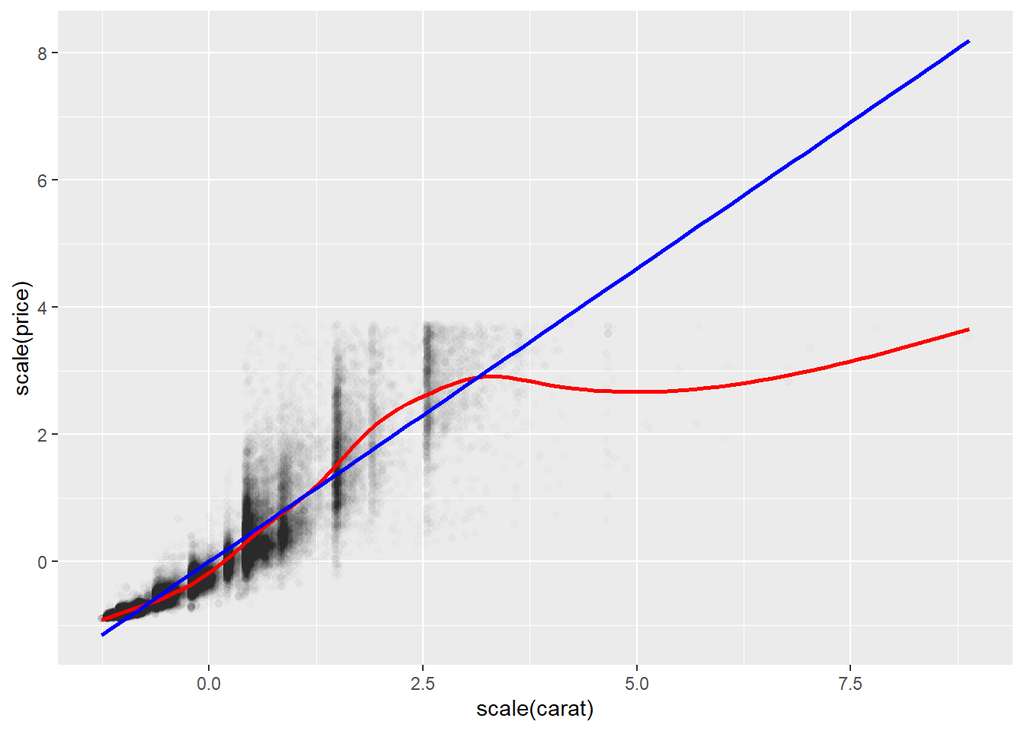

```r
ggplot(data = diamonds, mapping = aes(x = scale(carat), y = scale(price))) +
  geom_point(alpha = 1/100) +
  geom_smooth(color = "red", se = FALSE) +
  geom_smooth(method = "lm", color = "blue", se = FALSE)
```

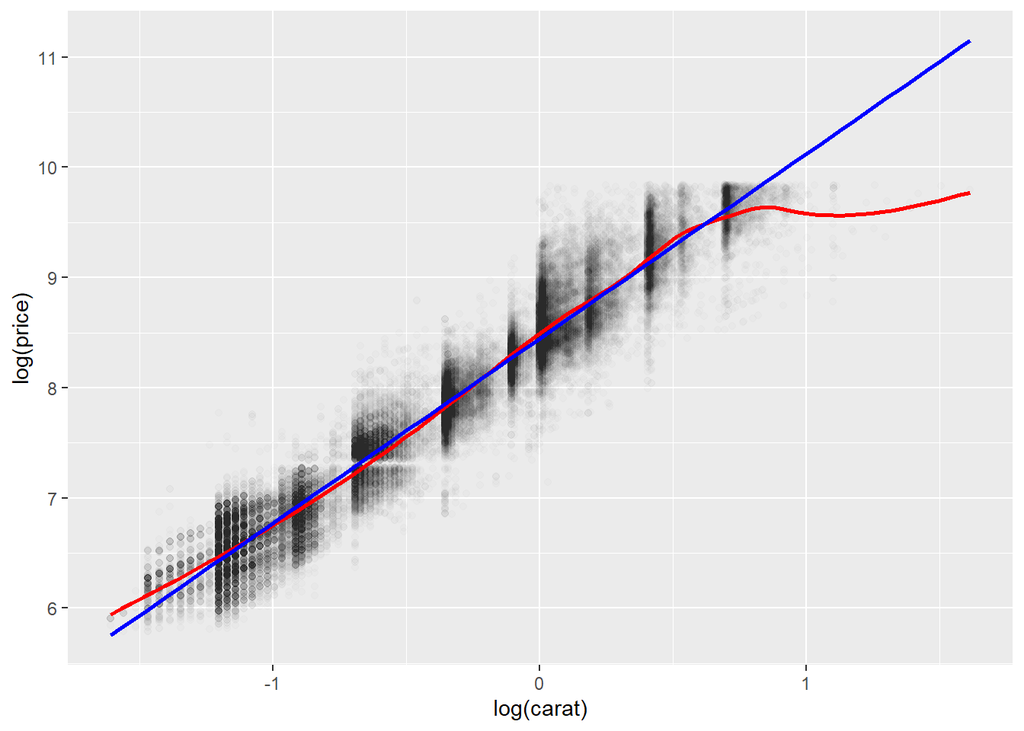

```r
ggplot(data = diamonds, mapping = aes(x = log(carat), y = log(price))) +
  geom_point(alpha = 1/100) +
  geom_smooth(color = "red", se = FALSE) +
  geom_smooth(method = "lm", color = "blue", se = FALSE)
```

## Rank the diamonds by weight and price

- Create two new variables called size_rank and price_rank where 1 means the largest
- View the largest diamonds by size
- View the largest diamonds by price

```r
largest <- diamonds %>%
  mutate(size_rank = min_rank(desc(carat)),
         price_rank = min_rank(desc(price)))

# Largest by size
largest %>%
  arrange(size_rank) %>%
  select(carat, size_rank)
```

```
## # A tibble: 53,940 x 2
##    carat size_rank
##    <dbl>     <int>
##  1  5.01         1
##  2  4.5          2
##  3  4.13         3
##  4  4.01         4
##  5  4.01         4
##  6  4            6
##  7  3.67         7
##  8  3.65         8
##  9  3.51         9
## 10  3.5         10
## # ... with 53,930 more rows
```

```r
head(10)
```

```
## [1] 10
```

```r
# Largest by price
largest %>%
  arrange(price_rank) %>%
  select(price, price_rank)
```

```
## # A tibble: 53,940 x 2
##    price price_rank
##    <int>      <int>
##  1 18823          1
##  2 18818          2
##  3 18806          3
##  4 18804          4
##  5 18803          5
##  6 18797          6
##  7 18795          7
##  8 18795          7
##  9 18791          9
## 10 18791          9
## # ... with 53,930 more rows
```

```r
head(10)
```

```
## [1] 10
```